# Multiple Testing, Selective Inference, and Conformal Inference

Alexander McLain

2025-11-19

```r
knitr::opts_chunk$set(echo = TRUE, cache = TRUE, message = FALSE, warning = FALSE)
library(plyr)
library(tidyverse)
library(rafalib)
# BiocManager::install("genefilter")
# BiocManager::install("multtest")
library(genefilter)
library(multtest) #Useful package for multiple testing and data
library(locfdr)
library(qvalue)
library(glmnet)
library(selectiveInference)
# library(devtools)
# install_github(repo="ryantibs/conformal", subdir="conformalInference")
library(conformalInference)
library(kableExtra)

kbl2 <- function(x, ...) kable(x, align = "lrrrrrr", ...) %>% kable_styling(full_width = FALSE)
set.seed(2025)
```

# Simulated Data Examples

```r
set.seed(1)
population = rnorm(1e7)
alpha <- 0.05
N <- 30
m <- 1000
pvals <- replicate(m,{
  control = sample(population,N)
  treatment = sample(population,N)
  t.test(treatment,control)$p.value
})
```

Let’s see what $R=V$ is for this experiment.

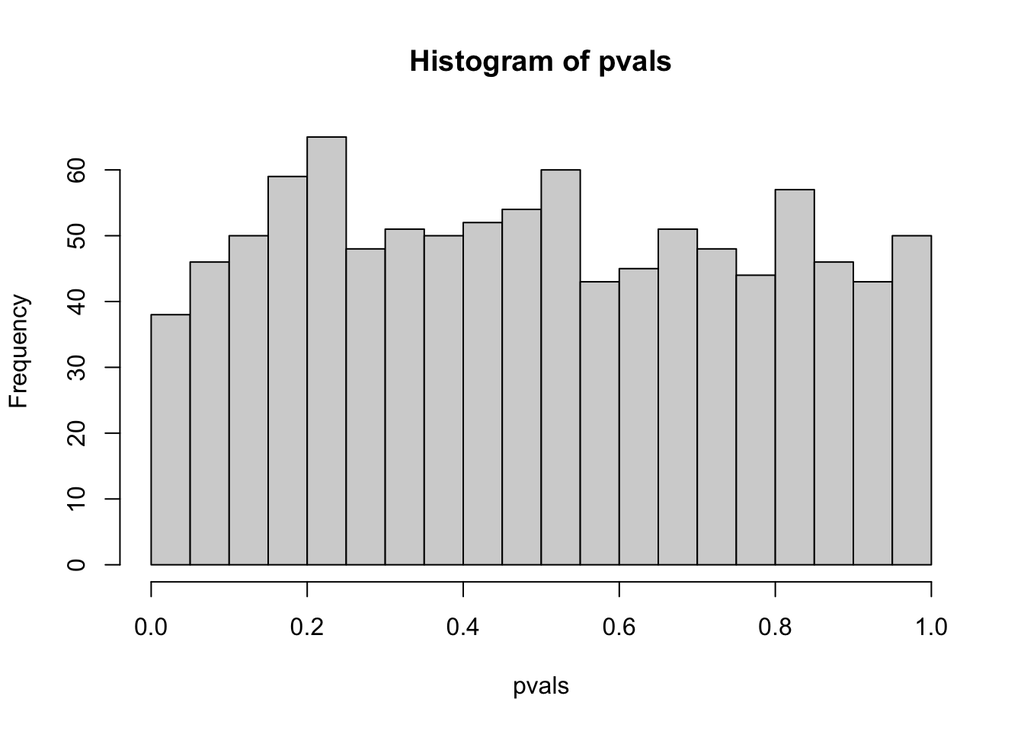

```r
hist(pvals, breaks = 30)
```

```r
sum(pvals < 0.05) ##This is R
```

```
## [1] 38
```

Now we’ll simulate some data where there is an affect of treatment. Let’s set up the values:

```r
alpha <- 0.05
N <- 12
m <- 1000
p0 <- 0.90 ##10% of hypotheses are signals, 90% are nulls
m0 <- m*p0
m1 <- m-m0
nullHypothesis <- c( rep(TRUE,m0), rep(FALSE,m1))
delta <- 1
```

Now, let’s simulate the data.

```r
set.seed(1)
N <- 30
g <- factor( c(rep(0,N),rep(1,N)) )
controls <- matrix(sample(population, N*m, replace=TRUE),nrow=m)
treatments <-  matrix(sample(population, N*m, replace=TRUE),nrow=m)
treatments[which(!nullHypothesis),]<-treatments[which(!nullHypothesis),]+delta
dat <- cbind(controls,treatments)
pvals <- rowttests(dat,g)$p.value
```

Let’s see how we did in our results:

```r
null_hypothesis <- factor( nullHypothesis, levels=c("TRUE","FALSE"))
calls_original <- ifelse( pvals < alpha,
          "Called Significant",
          "Not Called Significant")
table(null_hypothesis,calls_original) %>% kbl2()
```

|  | Called Significant | Not Called Significant |
| --- | --- | --- |
| TRUE | 43 | 857 |
| FALSE | 93 | 7 |

$$Q = \frac{V}{V+S} = \frac{V}{R}$$
if $R>0$ and $Q=0$ if $R = 0$.

Note that $V$, $S$, and $Q$ are random variables. If we run the simulation repeatedly, these values change. Here is a quick example:

```r
B <- 10 ##number of simulations
VandS <- replicate(B,{
  calls <- sapply(1:m, function(i){
    control <- sample(population,N)
    treatment <- sample(population,N)
    if(!nullHypothesis[i]) treatment <- treatment + delta
    t.test(treatment,control)$p.val < alpha
  })
  c(sum(nullHypothesis & calls),sum(!nullHypothesis & calls),sum(nullHypothesis & calls)/sum(calls))
})
tibble(S = VandS[2,], V = VandS[1,],  R = VandS[1,] + VandS[2,], Q = VandS[3,]) %>% kbl2(digits = 3)
```

| S | V | R | Q |
| --- | --- | --- | --- |
| 58 | 53 | 111 | 0.477 |
| 58 | 46 | 104 | 0.442 |
| 62 | 40 | 102 | 0.392 |
| 63 | 47 | 110 | 0.427 |
| 68 | 52 | 120 | 0.433 |
| 75 | 32 | 107 | 0.299 |
| 58 | 43 | 101 | 0.426 |
| 71 | 27 | 98 | 0.276 |
| 60 | 38 | 98 | 0.388 |
| 66 | 40 | 106 | 0.377 |

```r
tibble(Parameter = c("V", "S", "Q"), Avg_value = apply(VandS, 1, mean)) %>% kbl2(digits = 3)
```

| Parameter | Avg_value |
| --- | --- |
| V | 41.800 |
| S | 63.900 |
| Q | 0.394 |

## Family-Wise Error rate

To do an FWER correction we can use Bonfeerroni or the Holm procedure. These (alohg with other methods) can be fitted using the `p.adjust` function in R.

`p.adjust(p, method = p.adjust.methods, n = length(p))`

`p.adjust.methods = c("holm", "hochberg", "hommel", "bonferroni", "BH", "BY","fdr", "none")`

Controlling the FWER at 0.05 is a very conservative approach. Using the p-values computed in the previous section and compare the results.

```r
p_bonf <- p.adjust(pvals,method = "bonferroni")
p_holm <- p.adjust(pvals,method = "holm")

calls_bonf <- ifelse( p_bonf < alpha,
          "Called Significant",
          "Not Called Significant")
calls_holm <- ifelse( p_holm < alpha,
          "Called Significant",
          "Not Called Significant")
table(null_hypothesis,calls_original) %>% kbl2()
```

|  | Called Significant | Not Called Significant |
| --- | --- | --- |
| TRUE | 43 | 857 |
| FALSE | 93 | 7 |

```r
table(null_hypothesis,calls_bonf) %>% kbl2()
```

|  | Called Significant | Not Called Significant |
| --- | --- | --- |
| TRUE | 0 | 900 |
| FALSE | 33 | 67 |

```r
table(null_hypothesis,calls_holm) %>% kbl2()
```

|  | Called Significant | Not Called Significant |
| --- | --- | --- |
| TRUE | 0 | 900 |
| FALSE | 33 | 67 |

## False Discovery Rate

Let’s look at the BH procedure for the above data:

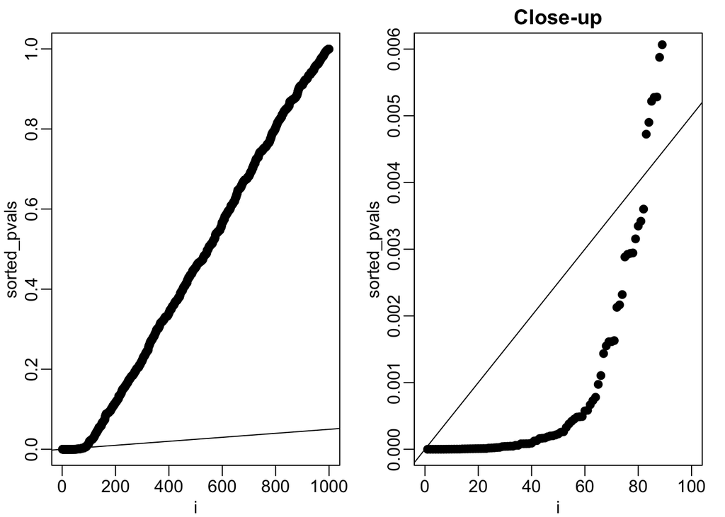

```r
alpha <- 0.05
i = seq(along=pvals)

mypar(1,2)
sorted_pvals = sort(pvals)
plot(i,sorted_pvals, pch = 19)
abline(0,i/m*alpha)
##close-up
plot(i,sorted_pvals, main="Close-up", pch = 19, xlim = c(0,100), ylim = c(0,0.006))
abline(0,i/m*alpha)
```

```r
k <- max( which( sort(pvals) < i/m*alpha) )
cutoff <- sort(pvals)[k]
cat("k =",k,", p-value cutoff=",cutoff)
```

```
## k = 82 , p-value cutoff= 0.003601054
```

With can do this much easier with `p.adjust`:

```r
q_bh <- p.adjust(pvals, method="fdr")

calls_bh <- ifelse( q_bh <= alpha,
          "Called Significant",
          "Not Called Significant")
table(null_hypothesis,calls_original) %>% kbl2()
```

|  | Called Significant | Not Called Significant |
| --- | --- | --- |
| TRUE | 43 | 857 |
| FALSE | 93 | 7 |

```r
table(null_hypothesis,calls_bonf) %>% kbl2()
```

|  | Called Significant | Not Called Significant |
| --- | --- | --- |
| TRUE | 0 | 900 |
| FALSE | 33 | 67 |

```r
table(null_hypothesis,calls_bh) %>% kbl2()
```

|  | Called Significant | Not Called Significant |
| --- | --- | --- |
| TRUE | 3 | 897 |
| FALSE | 79 | 21 |

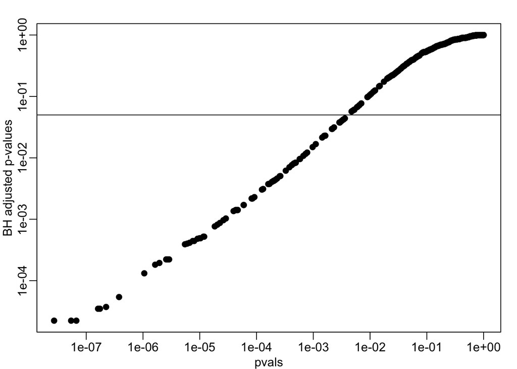

```r
mypar(1,1)
plot(pvals,q_bh,log="xy", pch = 19, ylab = "BH adjusted p-values")
abline(h=alpha)
```

We can run a Monte-Carlo simulation to confirm that the FDR is in fact lower than $0.05$. We compute all p-values first, and then use these to decide which are significant.

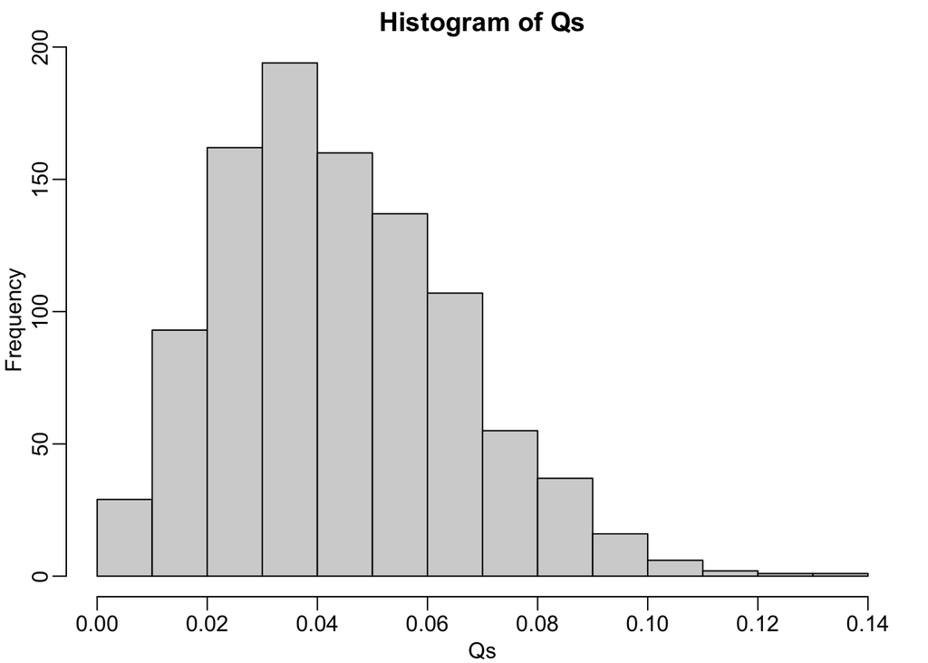

```r
alpha <- 0.05
N <- 30
g <- factor( c(rep(0,N),rep(1,N)) )
B <- 1000 ##number of simulations. We should increase for more precision
res <- replicate(B,{
  controls <- matrix(sample(population, N*m, replace=TRUE),nrow=m)
  treatments <-  matrix(sample(population, N*m, replace=TRUE),nrow=m)
  treatments[which(!nullHypothesis),]<-treatments[which(!nullHypothesis),]+delta
  dat <- cbind(controls,treatments)
  pvals <- rowttests(dat,g)$p.value
  ##Adjust for the FDR
  calls <- p.adjust(pvals,method="fdr") < alpha
  R=sum(calls)
  Q=ifelse(R>0,sum(nullHypothesis & calls)/R,0)
  return(c(R,Q))
})
Qs <- res[2,]
Rs <- res[1,]
mypar(1,1)
hist(Qs) ##Q is a random variable, this is its distribution
```

```r
tibble(Statistics = attr(summary(Qs), "names"), Value = summary(Qs)) %>% kbl2(digits = 3)
```

| Statistics | Value |
| --- | --- |
| Min. | 0.00000 |
| 1st Qu. | 0.02564 |
| Median | 0.04372 |
| Mean | 0.04404 |
| 3rd Qu. | 0.05882 |
| Max. | 0.13953 |

Note that the BH procedure doesn’t gaurentee that the $FDR \leq \alpha$ - the opposite can be true. However, on average $FDR \leq \alpha$. In fact, for the BH procedure $E(FDR) = \pi_0 \alpha$ where $\pi_0\leq 1$ is the proportion of null hypothesis. Here, $\pi_0 = 0.9$ so we would expect the FDR for the BH to ba around $0.045 = 0.9 \times 0.05$.

```r
 ## Number of correct rejections
tibble(Statistics = attr(summary(Rs*(1-Qs)), "names"), Value = summary(Rs*(1-Qs))) %>% kbl2(digits = 3)
```

| Statistics | Value |
| --- | --- |
| Min. | 65.0 |
| 1st Qu. | 78.0 |
| Median | 81.0 |
| Mean | 80.8 |
| 3rd Qu. | 84.0 |
| Max. | 93.0 |

## Q-values (optional)

In this Section we’ll use the q-value approach from Storey and Tibshraini (2003). To do this we’ll first estimate $\pi_0$. When doing this we’ll use $\lambda = 0.1$, which is the value I usually use in practice as it has been shown to be robust to dependence in the p-values.

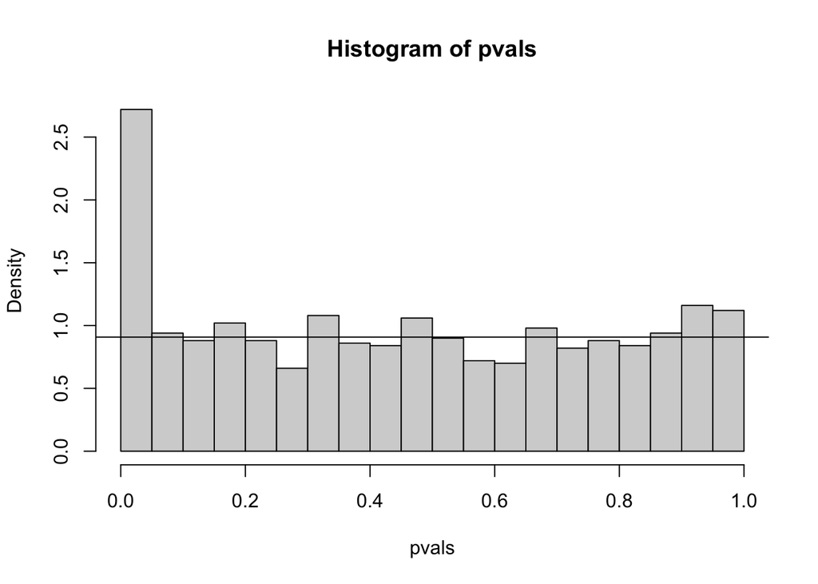

```r
hist(pvals,breaks=seq(0,1,0.05),freq=FALSE)
lambda = 0.1
pi0=sum(pvals> lambda) /((1-lambda)*m)
abline(h= pi0)
```

```r
print(round(pi0, 3))
```

```
## [1] 0.908
```

Then, using the relationship between the BH and Storey procedures that we discussed, the estimated q_values are:

```r
q_st <- p.adjust(pi0*pvals, method="fdr")
calls_st <- ifelse( q_st <= alpha,
          "Called Significant",
          "Not Called Significant")
table(null_hypothesis,calls_st)%>% kbl2()
```

|  | Called Significant | Not Called Significant |
| --- | --- | --- |
| TRUE | 3 | 897 |
| FALSE | 79 | 21 |

```r
table(null_hypothesis,calls_bh) %>% kbl2()
```

|  | Called Significant | Not Called Significant |
| --- | --- | --- |
| TRUE | 3 | 897 |
| FALSE | 79 | 21 |

This can all be done using the *qvalue* package (available on bioconductor not CRAN):

```r
res <- qvalue(pvals)
qvals <- res$qvalues
```

The `qvalue` package contains multiple methods to estimate $\pi_0$ see `?pi0est` for details.

# Example of leukemia data

We’ll illustrate the multiple testing methods with gene expression data from the leukemia ALL/AML study of Golub et al. (1999). Load the leukemia dataset:

```r
data(golub)
dim(golub)
```

```
## [1] 3051   38
```

Each column is a sample (subject), and $golub_{j, i}$ is the expression level for gene $j$ in tumor mRNA sample $i$. All of the genes have identifiers and tumor class labelss (0 for ALL, 1 for AML).

```r
dim(golub.gnames)
```

```
## [1] 3051    3
```

```r
golub.gnames[1:4, ]
```

```
##      [,1] [,2]
## [1,] "36" "AFFX-HUMISGF3A/M97935_MA_at (endogenous control)"
## [2,] "37" "AFFX-HUMISGF3A/M97935_MB_at (endogenous control)"
## [3,] "38" "AFFX-HUMISGF3A/M97935_3_at (endogenous control)"
## [4,] "39" "AFFX-HUMRGE/M10098_5_at (endogenous control)"
##      [,3]
## [1,] "AFFX-HUMISGF3A/M97935_MA_at"
## [2,] "AFFX-HUMISGF3A/M97935_MB_at"
## [3,] "AFFX-HUMISGF3A/M97935_3_at"
## [4,] "AFFX-HUMRGE/M10098_5_at"
```

```r
golub.cl
```

```
##  [1] 0 0 0 0 0 0 0 0 0 0 0 0 0 0 0 0 0 0 0 0 0 0 0 0 0 0 0 1 1 1 1 1 1 1 1 1 1 1
```

We’ll use the *rowttests* to compute the p-values (t-tests on each row):

```r
p_vals <- rowttests( golub, factor(golub.cl) )$p.value
```

Let’s take a look at a histogram of the p-values, and estimate the proportion of null hypotheses:

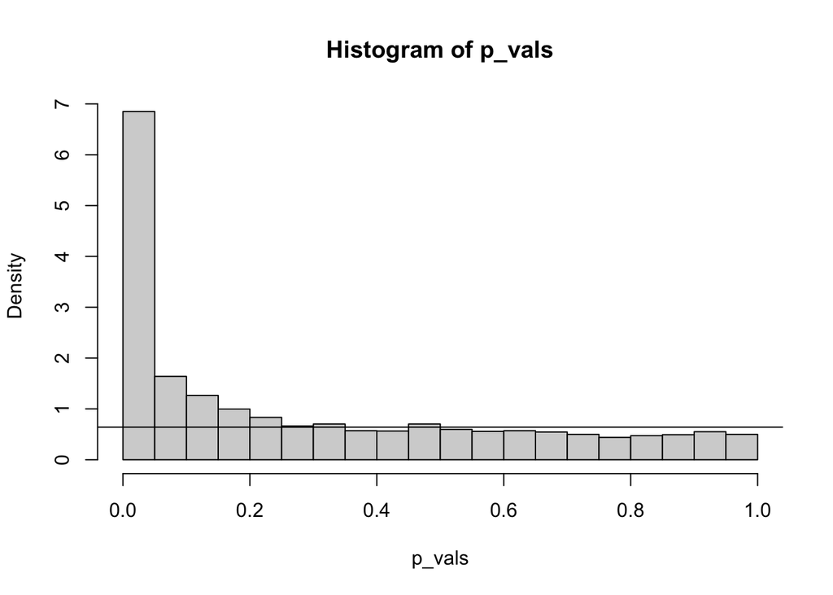

```r
m <- nrow(golub)
hist(p_vals,breaks=seq(0,1,0.05),freq=FALSE)
lambda = 0.1
pi0=sum(p_vals> lambda) /((1-lambda)*m)
abline(h= pi0)
```

```r
print(round(pi0, 3))
```

```
## [1] 0.639
```

So, this estimates that only $\sim 64\%$ of the genes are trully a null hypothesis.

Now let’s implement all of the methods to the p-values.

```r
p_bonf <- p.adjust(p_vals, method = "bonf")
q_bh <- p.adjust(p_vals, method = "fdr")
q_st <- qvalue(p_vals)
data.frame("Bonf" = sum(p_bonf < 0.05), "BH" = sum(q_bh < 0.05), "Storey" = sum(q_st$qvalues < 0.05))
```

```
##   Bonf  BH Storey
## 1   98 681    876
```

To display the results we can use a Manhattan plot:

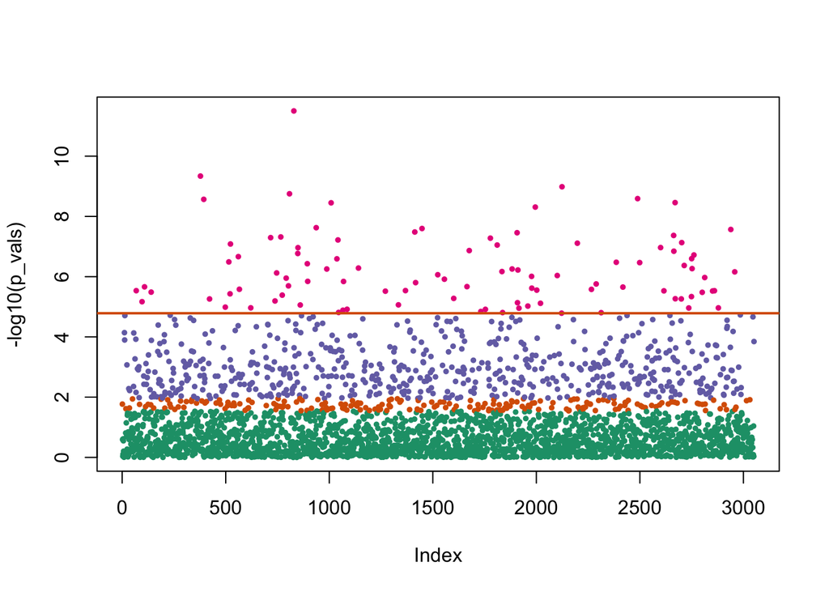

```r
plot(-log10(p_vals), col = 1 + 1*I(p_bonf < 0.05) + 1*I(q_bh < 0.05)
     + 1*I(q_st$qvalues < 0.05), pch = 19, cex = 0.5)
abline(h = log10(m/alpha), lwd = 2, col = 2)
```

# Selective Inference

## Data Splitting

Below is an example in R using the bodyfat dataset used previously. We’ll use the `glmnet` package for the LASSO regression.

This is a basic illustration and the bodyfat dataset might not be high-dimensional enough to warrant a LASSO, but it serves well to explain the concept:

We first load the `glmnet` package, which provides tools to fit LASSO models.

```r
# Use the bodyfat dataset
bf_dat <- read.csv("bodyfat2.csv")
# Take off body density
bf_df <- data.frame(bf_dat)[, -1]
```

Split it into a training set (selection set) for model selection and a test set (inference set) for inference.

```r
# Setting the seed for reproducibility
set.seed(123)

# Split the data into a training (selection) set and a test (inference) set
train_indices <- sample(1:nrow(bf_df),
                        floor(nrow(bf_df)*0.5))
train_data <- bf_df[train_indices, ]
test_data <- bf_df[-train_indices, ]
```

We fit a LASSO regression on the training set and identify the predictors selected by the LASSO.

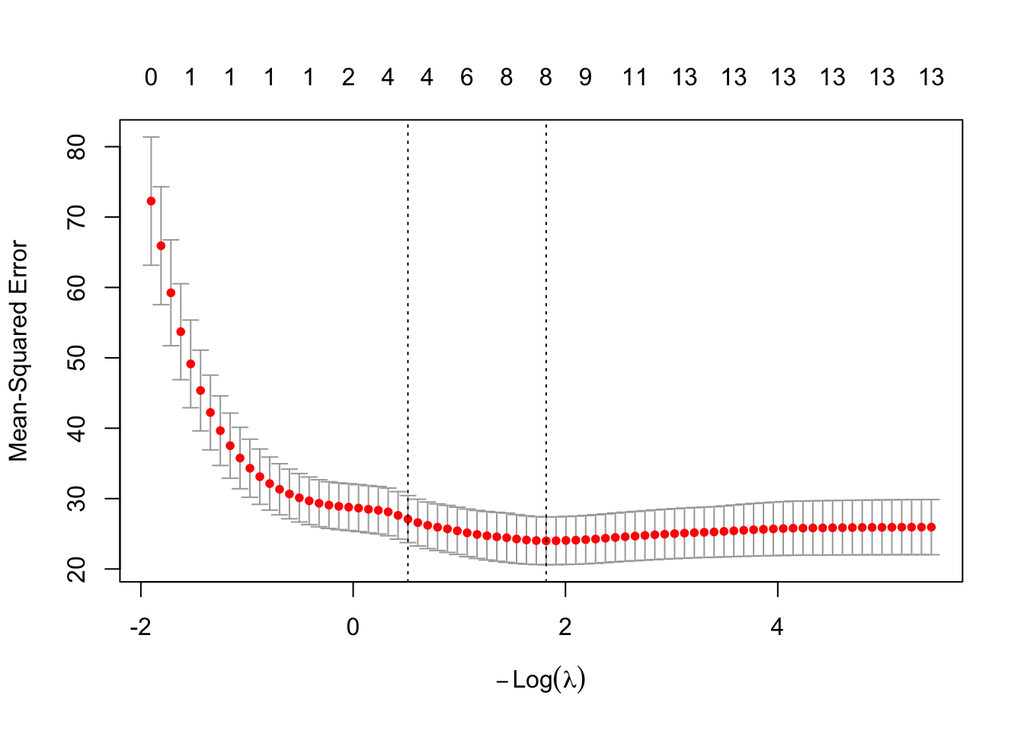

```r
# Fit the LASSO model on the training data
x_train <- as.matrix(train_data[, -1])
y_train <- train_data[, 1]
lasso_model <- cv.glmnet(x_train, y_train, alpha = 1, grouped = FALSE)
plot(lasso_model)
```

```r
# Predictors selected by LASSO
coef_lasso <- coef(lasso_model, s = lasso_model$lambda.min)
coef_lasso
```

```
## 14 x 1 sparse Matrix of class "dgCMatrix"
##             s=0.1622797
## (Intercept)  3.32272889
## age          0.09644498
## weight       .
## height      -0.23229759
## neck        -0.49906487
## chest        .
## abdomen      0.67862648
## hip          .
## thigh        .
## knee         .
## ankle        0.14386938
## biceps       0.13904008
## forearm      0.29377424
## wrist       -1.76170519
```

```r
selected_predictors <- colnames(x_train)[which(coef_lasso != 0)[-1]]
```

Using only the selected predictors, we fit an ordinary least squares (OLS) regression on the test set.

```r
# Fit an OLS regression on the test data using only the selected predictors
x_test <- as.matrix(test_data[, which(coef_lasso != 0)[-1]])
y_test <- test_data[, 1]
ols_model <- lm(y_test ~ x_test)

# Display the summary of the OLS model
summary(ols_model)$coefficients %>% kbl2(digits = 3)
```

|  | Estimate | Std. Error | t value | Pr(>&#124;t&#124;) |
| --- | --- | --- | --- | --- |
| (Intercept) | 1.147 | 10.780 | 0.106 | 0.915 |
| x_testage | 0.011 | 0.039 | 0.278 | 0.782 |
| x_testheight | -0.362 | 0.170 | -2.129 | 0.035 |
| x_testneck | -0.256 | 0.329 | -0.779 | 0.438 |
| x_testabdomen | 0.823 | 0.060 | 13.688 | 0.000 |
| x_testankle | -0.317 | 0.291 | -1.089 | 0.278 |
| x_testbiceps | -0.011 | 0.252 | -0.042 | 0.966 |
| x_testforearm | 0.103 | 0.485 | 0.212 | 0.832 |
| x_testwrist | -1.036 | 0.818 | -1.266 | 0.208 |

## Selective Inference Tools

Here we’ll use the R package named `selectiveInference` developed by the authors who pioneered this concept. It provides selective inference for LASSO, among other things.

Here’s a simple example using the `bf_df` dataset.

```r
X <- as.matrix(bf_df[, -1])
y <- bf_df[, 1]
```

Using the selective inference package requires that `x` should be centered,

```r
x <- scale(X, TRUE, TRUE)
```

Fit a LASSO model using `cv.glmnet`:

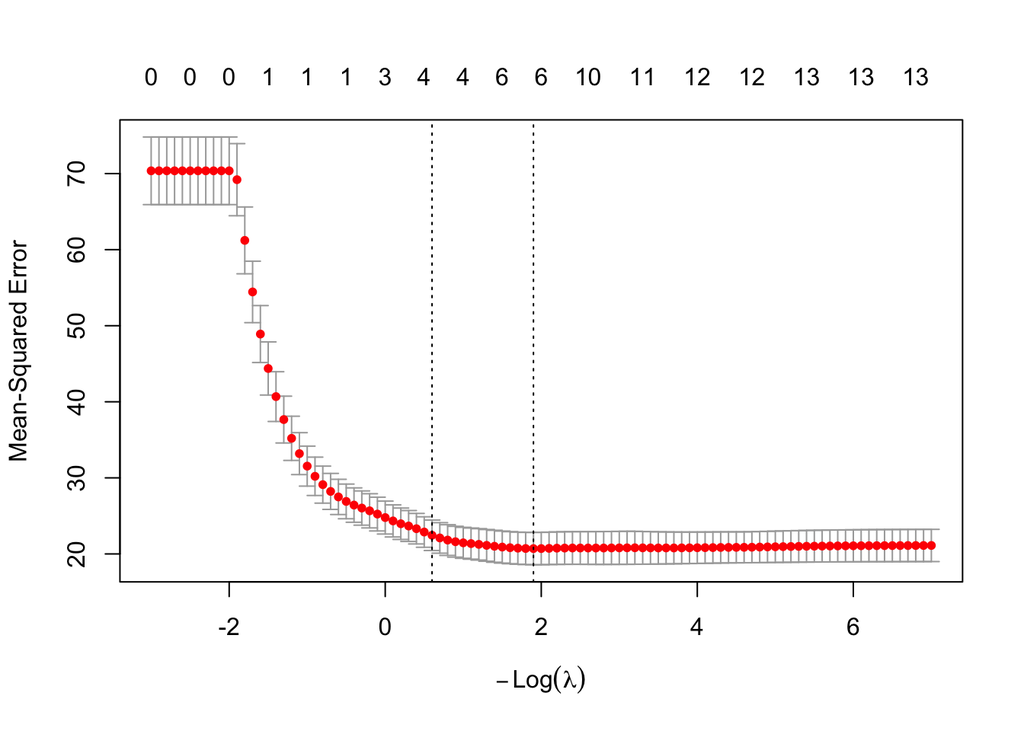

```r
fit <- cv.glmnet(x, y, alpha=1,
              standardize = FALSE,
              intercept = TRUE,
              lambda = exp(seq(-7,3,0.1)) )

par(mfrow=c(1,1))
plot(fit)
```

```r
lambda <- fit$lambda.1se
# extract coef for a given lambda minus the intercept term
beta <- coef(fit, x=x, y=y, s = lambda, exact = TRUE)[-1]
tibble(var = colnames(x), beta = beta) %>% kbl2(digits = 3)
```

| var | beta |
| --- | --- |
| age | 0.299 |
| weight | 0.000 |
| height | -0.667 |
| neck | 0.000 |
| chest | 0.000 |
| abdomen | 6.576 |
| hip | 0.000 |
| thigh | 0.000 |
| knee | 0.000 |
| ankle | 0.000 |
| biceps | 0.000 |
| forearm | 0.000 |
| wrist | -0.423 |

Apply the `fixedLassoInf` function from the `selectiveInference` package:

```r
# Fit to the data (note the scaling of lambda by n)
result <- fixedLassoInf(x, y, beta, lambda = lambda * nrow(x))
print(result)
```

```
Call:
fixedLassoInf(x = x, y = y, beta = beta, lambda = lambda * nrow(x))

Standard deviation of noise (specified or estimated) sigma = 4.309

Testing results at lambda = 138.301, with alpha = 0.100

 Var   Coef Z-score P-value LowConfPt UpConfPt LowTailArea UpTailArea
   1  0.828   2.749   0.075    -0.138    1.312       0.050      0.050
   3 -0.762  -2.388   0.022    -1.319   -0.153       0.049      0.049
   6  7.933  22.684   0.000     7.247    8.510       0.049      0.049
  13 -1.890  -4.946   0.006    -2.515   -0.768       0.048      0.049

Note: coefficients shown are partial regression coefficients
```

The result will provide selective p-values for the coefficients, among other things. Note that the coefficients and standard errors reported are **unregularized**. Eg for the Gaussian, they are the usual least squares estimates and standard errors for the model fit to the active set from the lasso.

Remember, these p-values account for the model selection process and provide a valid inference even when considering the adaptiveness of LASSO.

This function also works for logistic and Cox models with the lasso penalty.